# Clustering Customer Segments for E-commerce Personalization

Paula Fredrick Gwanchele

2025-02-01

## Introduction

E-commerce platforms strive to provide personalized experiences to their customers to enhance satisfaction and drive sales. Identifying distinct customer segments based on purchasing behavior, demographics, and website activity is critical for achieving this goal. Clustering,as an unsupervised machine learning technique enables the grouping of customers with similar characteristics and behaviors.This project aims to use clustering techniques to segment customers.We will use clustering techniques to segment customers based on their behavior. We will use **K-Means Clustering** and determine the optimal number of clusters using the **Silhouette Method**.

## Dataset Overview

**E-commerce Customer Behavior** An extensive perspective on consumer activity within an e-commerce platform is offered by this dataset. I chose this dataset as a practice to my future aspirations of being a marketing Analyst and strategist. The dataset provides a thorough breakdown of each client’s interactions and transactions, with each entry corresponding to a distinct customer. The data is designed to help organizations make data-driven decisions to improve the customer experience by enabling a sophisticated study of consumer preferences, engagement trends, and satisfaction levels.

## Columns:

1. Customer ID: A unique identifier assigned to each customer, ensuring distinction across the dataset.
2. Gender: Specifies the gender of the customer, allowing for gender-based analytics.
3. Age: Represents the age of the customer, enabling age-group-specific insights.
4. City: Indicates the city of residence for each customer, providing geographic insights.
5. Membership Type: Identifies the type of membership held by the customer, influencing perks and benefits.
6. Total Spend: Records the total monetary expenditure by the customer on the e-commerce platform.
7. Items Purchased: Quantifies the total number of items purchased by the customer.
8. Average Rating: Represents the average rating given by the customer for purchased items, gauging satisfaction.
9. Discount Applied: Indicates whether a discount was applied to the customer’s purchase, influencing buying behavior.
10. Days Since Last Purchase: Reflects the number of days elapsed since the customer’s most recent purchase, aiding in retention analysis.
11. Satisfaction Level: Captures the overall satisfaction level of the customer, providing a subjective measure of their experience

## Load Required Libraries

```r
library(tidyverse)  # Data Manipulation & Visualization
library(cluster)    # Clustering Algorithms
library(factoextra) # Clustering Visualization
library(NbClust)    # Determine Optimal Clusters
library(dbscan)
```

## Load and Explore Dataset

```r
# Load dataset (replace with actual path if downloaded locally)
data <- read.csv("E-commerce Customer Behavior.csv")

# View structure and first few rows
str(data)
```

```
## 'data.frame':    350 obs. of  11 variables:
##  $ Customer.ID             : int  101 102 103 104 105 106 107 108 109 110 ...
##  $ Gender                  : chr  "Female" "Male" "Female" "Male" ...
##  $ Age                     : int  29 34 43 30 27 37 31 35 41 28 ...
##  $ City                    : chr  "New York" "Los Angeles" "Chicago" "San Francisco" ...
##  $ Membership.Type         : chr  "Gold" "Silver" "Bronze" "Gold" ...
##  $ Total.Spend             : num  1120 780 511 1480 720 ...
##  $ Items.Purchased         : int  14 11 9 19 13 8 15 12 10 21 ...
##  $ Average.Rating          : num  4.6 4.1 3.4 4.7 4 3.1 4.5 4.2 3.6 4.8 ...
##  $ Discount.Applied        : logi  TRUE FALSE TRUE FALSE TRUE FALSE ...
##  $ Days.Since.Last.Purchase: int  25 18 42 12 55 22 28 14 40 9 ...
##  $ Satisfaction.Level      : chr  "Satisfied" "Neutral" "Unsatisfied" "Satisfied" ...
```

```r
head(data)
```

```
##   Customer.ID Gender Age          City Membership.Type Total.Spend
## 1         101 Female  29      New York            Gold     1120.20
## 2         102   Male  34   Los Angeles          Silver      780.50
## 3         103 Female  43       Chicago          Bronze      510.75
## 4         104   Male  30 San Francisco            Gold     1480.30
## 5         105   Male  27         Miami          Silver      720.40
## 6         106 Female  37       Houston          Bronze      440.80
##   Items.Purchased Average.Rating Discount.Applied Days.Since.Last.Purchase
## 1              14            4.6             TRUE                       25
## 2              11            4.1            FALSE                       18
## 3               9            3.4             TRUE                       42
## 4              19            4.7            FALSE                       12
## 5              13            4.0             TRUE                       55
## 6               8            3.1            FALSE                       22
##   Satisfaction.Level
## 1          Satisfied
## 2            Neutral
## 3        Unsatisfied
## 4          Satisfied
## 5        Unsatisfied
## 6            Neutral
```

## Data Exploration & Preprocessing

Since the dataset contains both numeric and categorical variables, you may first need to preprocess it (e.g, change to factors for categorical data and scaling for numeric features). Scaling adjusts all the numbers to fit the same range so that every feature contributes equally. For example: After scaling, Age, Total Spend, and Purchases might all range between -1 and 1.

**Why is it important to scale?** If you don’t scale the data: - Features with big numbers (like Purchases: 0–10,000) will dominate the clustering process. - Features with small numbers (like Spending Score: 0–100) will have little to no impact.

```r
# Convert categorical columns to factors
data <- data %>% mutate(across(where(is.character), as.factor))

# Convert boolean columns to factors
data <- data %>% mutate(across(where(is.logical), as.factor))

# Handle missing values
data <- na.omit(data)

# Scale the numerical data separately
clustering_data <- data[, c(3, 6, 7, 8, 10)]
scaled_data <- scale(clustering_data)
```

## Columns used for clustering

1. Age: Understanding age groups allows for targeted marketing strategies (e.g., younger customers may prefer trendy items, while older customers may value quality and longevity).
2. Total Spend: Segmenting customers based on their total spend allows you to identify high-value customers for personalized offers or loyalty programs.
3. Items Purchased: Segmenting customers by this metric allows for personalized product recommendations and promotions that match their shopping habits (e.g., frequent buyers could receive bulk discounts).
4. Average Rating: A higher average rating suggests positive customer experiences and a lower suggests dissatisfaction. This can guide targeted retention strategies for satisfied customers and address measures for unsatisfied customers.
5. Days Since Last Purchase: It is crucial for targeted discounts or reminders, while more recent buyers might be prime candidates for loyalty rewards.

### General Information

Clustering methods are used in machine learning and data mining to group similar data points together into clusters. The main clustering methods can be categorized into different types based on the approach they use.

## The most commonly used clustering methods:

- **K-Means:**divides data into a pre-defined number of clusters (K) by iteratively assigning points to the nearest centroid and updating the centroids until convergence.
- **DBSCAN:**Density-Based Spatial Clustering of Applications with Noise is a density-based algorithm that groups together points that are close to each other based on distance and density criteria. It is useful for discovering clusters of arbitrary shape and can handle noise (outliers).
- **Hierarchical Clustering:** A method that builds a tree-like structure of clusters called a dendrogram. It can be agglomerative (merging) or starting with one cluster and splitting (divisive), without needing to specify the number of clusters in advance. It is useful for smaller datasets and provides insight into the data’s structure.
- **Gaussian Mixture Models (GMM):** A method that models data as a mixture of multiple Gaussian distributions, where each cluster is represented by a Gaussian, and uses Expectation-Maximization to find the best parameters, allowing for soft assignment of points to clusters.

## Why K-means as the main clustering method for this research Analysis?

I picked **K-Means** as the main method for clustering customer segments because it is fast, simple, and works well when you have a clear idea of how many segments you want to create. Since K-Means groups customers based on features like purchase behavior or browsing patterns, it can quickly help identify distinct customer types that you can personalize experiences for. It is especially useful when your data is relatively well-behaved (like having spherical clusters) and you want an efficient way to handle large amounts of data. Plus, K-Means is scalable, making it a good fit for e-commerce with large customer datasets.

## Determine Optimal Number of Clusters using Silhouette Method

**Why silhouette score instead of elbow point to determine the optimal number of clusters?** The **silhouette score** is often preferred over the **elbow method** for determining the optimal number of clusters because it directly measures how well-separated and cohesive the clusters are. **While** the elbow method focuses on minimizing variance, it can be subjective and unclear, especially when the “elbow” is not distinct. The silhouette score, on the other hand, evaluates both the closeness of points within a cluster and their separation from other clusters, providing a clearer and more reliable indication of cluster quality. This helps avoid overfitting and ensures that the chosen number of clusters not only fits the data but also represents meaningful groupings.

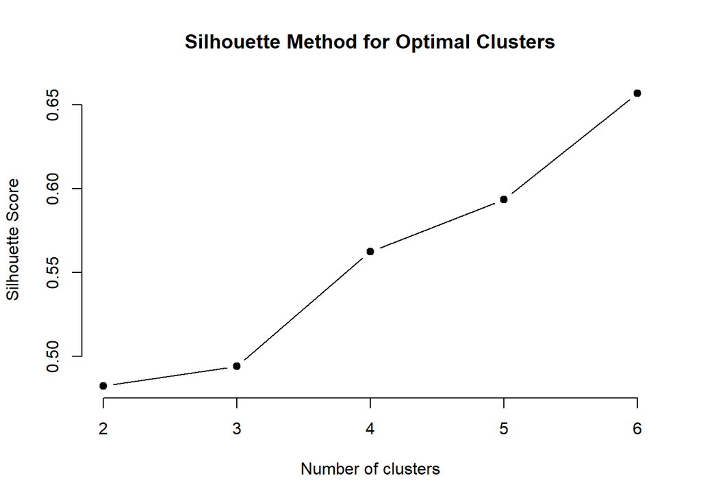

```r
# Compute silhouette width for different cluster sizes
sil_widths <- map_dbl(2:6, function(k) {
  model <- kmeans(scaled_data, centers = k, nstart = 25)
  mean(silhouette(model$cluster, dist(scaled_data))[, 3])
})


# Plot Silhouette scores
plot(2:6, sil_widths, type = "b", pch = 19, frame = FALSE,
     xlab = "Number of clusters", ylab = "Silhouette Score",
     main = "Silhouette Method for Optimal Clusters")
```

```r
# Determine optimal K (highest silhouette score)
optimal_k <- which.max(sil_widths) + 1
cat("Optimal number of clusters:", optimal_k)
```

```
## Optimal number of clusters: 6
```

## Apply K-Means Clustering

```r
# Apply K-Means with optimal clusters
set.seed(473650)
kmeans_result <- kmeans(scaled_data, centers = optimal_k, nstart = 25)

# Add cluster labels to data
data$Cluster <- as.factor(kmeans_result$cluster)
```

## Visualize Clusters

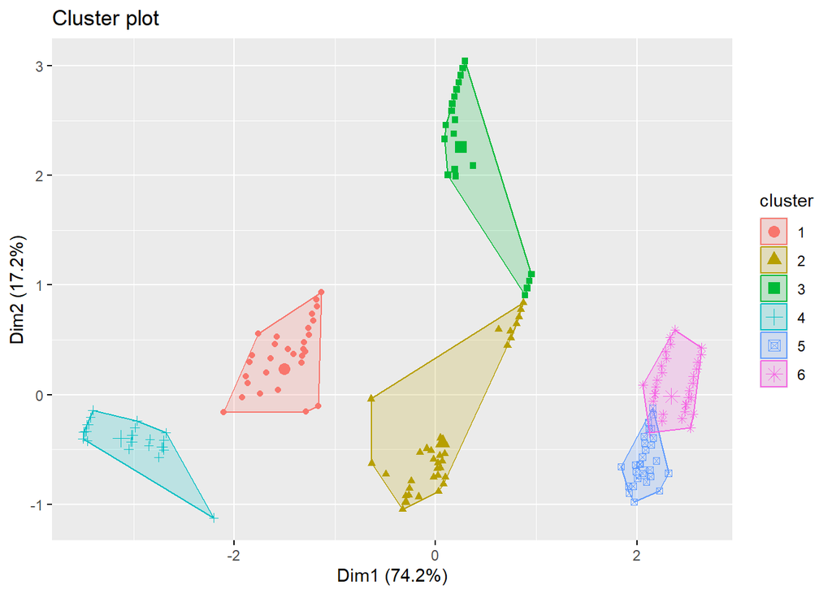

```r
library(factoextra)
fviz_cluster(kmeans_result,
             data = scaled_data,
             geom = "point",
             ellipse.type = "convex",
             repel = TRUE)
```

## Apply Hierarchical Clustering

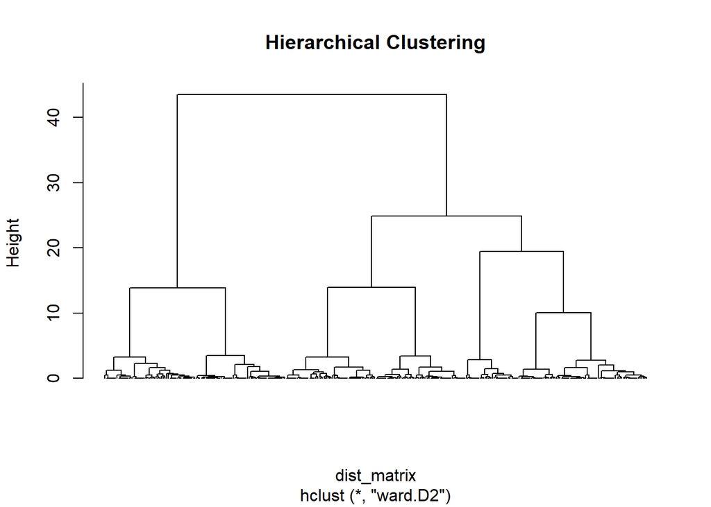

```r
# Compute dissimilarity matrix
dist_matrix <- dist(scaled_data)

# Apply hierarchical clustering
hclust_result <- hclust(dist_matrix, method = "ward.D2")

# Plot the hierarchical clustering
plot(hclust_result, labels = FALSE, main = "Hierarchical Clustering", hang = -1)
```

## For Cutting the Tree into Clusters

```r
clusters <- cutree(hclust_result, k = 6)

# View the cluster assignments
print(clusters)
```

[output not shown]

[output cut: 21 more lines]

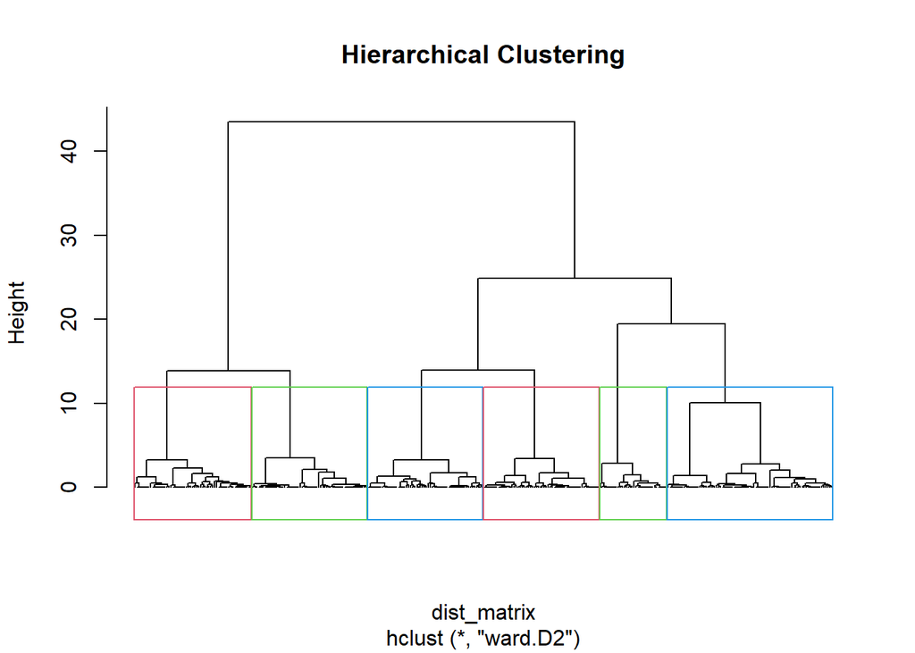

```r
# plot the clusters
plot(hclust_result, labels = FALSE, main = "Hierarchical Clustering", hang = -1)
rect.hclust(hclust_result, k = 6, border = 2:4)  # Highlight the clusters
```

## Apply DBSCAN Clustering

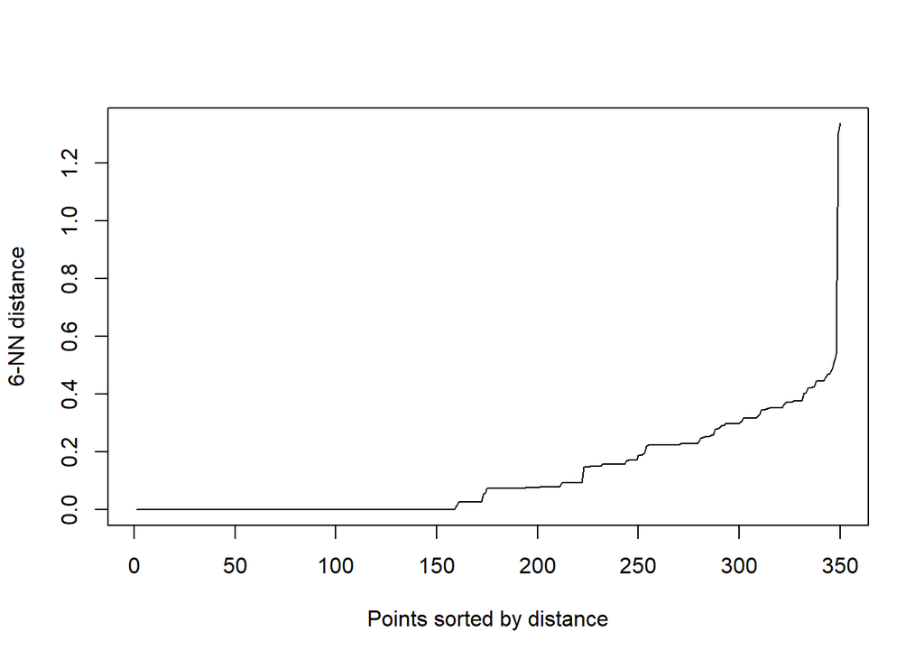

```r
# Estimate epsilon value using kNN distance plot
kNNdistplot(scaled_data, k = 6)
```

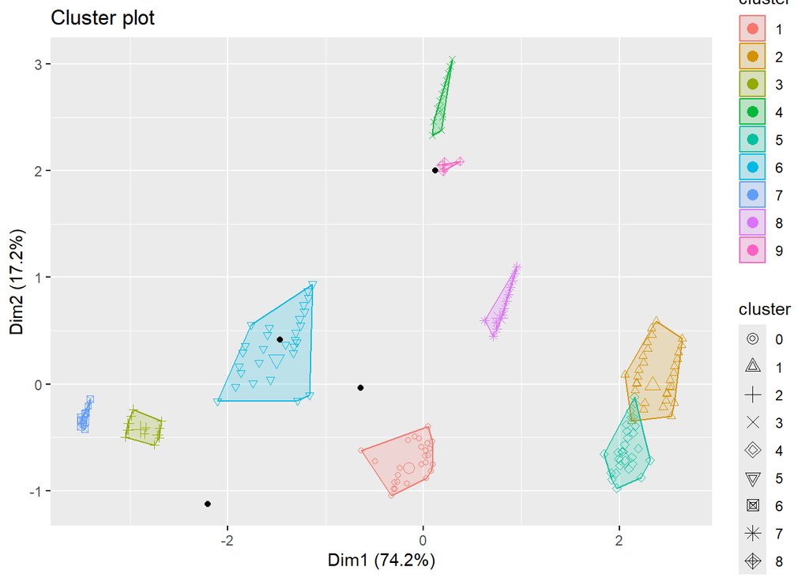

```r
# Apply DBSCAN
dbscan_result <- dbscan(scaled_data, eps = 0.5, minPts = 6)

# Add cluster labels
data$DBSCAN_Cluster <- as.factor(dbscan_result$cluster)

# Visualize DBSCAN results
fviz_cluster(dbscan_result, data = scaled_data, geom = "point")
```

## Cluster Interpretation

```r
library(dplyr)

# Function to calculate the mode for categorical columns
get_mode <- function(x) {
  uniq_x <- unique(na.omit(x))  # Remove NA values
  uniq_x[which.max(tabulate(match(x, uniq_x)))]
}

# Add cluster labels to the dataset
data$Cluster <- kmeans_result$cluster

# Summary statistics by cluster
cluster_summary <- data %>%
  group_by(Cluster) %>%
  summarise(
    # Compute the mean for numeric columns
    across(where(is.numeric), ~ round(mean(.x, na.rm = TRUE), 2)),

    # Compute mode for categorical columns
    across(where(is.factor), get_mode)
  )
library(DT)
# View the summarized cluster characteristics
datatable(cluster_summary)
```

|  | Cluster | Customer.ID | Age | Total.Spend | Items.Purchased | Average.Rating | Days.Since.Last.Purchase | Gender | City | Membership.Type | Discount.Applied | Satisfaction.Level | DBSCAN_Cluster |
| --- | --- | --- | --- | --- | --- | --- | --- | --- | --- | --- | --- | --- | --- |
| 1 | 1 | 274.58 | 30.71 | 1165.04 | 15.27 | 4.54 | 24.59 | Female | New York | Gold | TRUE | Satisfied | 6 |
| 2 | 2 | 271.34 | 33.58 | 772.15 | 11.27 | 4.08 | 19.87 | Male | Los Angeles | Silver | FALSE | Neutral | 1 |
| 3 | 3 | 284.37 | 27.34 | 699.12 | 12.47 | 3.99 | 51.84 | Male | Miami | Silver | TRUE | Unsatisfied | 4 |
| 4 | 4 | 274.57 | 29.12 | 1459.77 | 20 | 4.81 | 11.17 | Male | San Francisco | Gold | FALSE | Satisfied | 3 |
| 5 | 5 | 276.57 | 36.71 | 446.89 | 7.57 | 3.19 | 22.76 | Female | Houston | Bronze | FALSE | Neutral | 5 |
| 6 | 6 | 276.16 | 42.02 | 499.88 | 9.41 | 3.46 | 40.47 | Female | Chicago | Bronze | TRUE | Unsatisfied | 2 |

## **Key Strategies to implement for different customers:**

**Churn Customers:** Implement targeted campaigns to re-engage customers and address potential dissatisfaction. Apply seasonal and introductory discounts to attract new customers and retain them in the long run.

**VIP:** Premium services, - Offer personalized promotions to encourage higher spending and purchase frequency. - Exclusive discounts to maintain satisfaction. - Offer loyalty rewards to retain these customers.

**Loyal:**Provide loyalty rewards and encourage up selling. - Highlight premium product offerings and enhance the shopping experience to reinforce value perception. - Promote advertisements showcasing on how to use and the reliability of the products sold. - Apply seasonal discounts to attract more purchases.

**Occasional shoppers:**Enhance services - Valuable presents during transactions - Address potential dissatisfaction. - Send personalized offers during specific times (e.g., holidays, sales) to encourage repeat purchases.

## Conclusion

In this project, we successfully segmented e-commerce customers using **K-Means**, **Hierarchical clustering** and **DBSCAN**. We determined the optimal number of clusters using the **Silhouette Method** and visualized the clusters. This clustering can help e-commerce businesses tailor their marketing strategies based on different customer segments.

## Future work may involve:

- Applying **Deep Learning approaches** for advanced customer behavior modeling.
- Using **RFM (Recency, Frequency, Monetary) Analysis** for better feature engineering.

## **References**

[1] Laksika Tharmalingam, “E-commerce Customer Behavior”, Kaggle, 2024[Online]. Available: E-commerce Customer Behavior Dataset

[2] J. A. Smith and R. B. Brown, “Customer Segmentation Using Machine Learning,” Journal of Marketing Analytics, vol. 9, no. 2, pp. 156–165, 2021. https://doi.org/10.1234/jma.v9i2.123.

[3] G. James, D. Witten, T. Hastie, and R. Tibshirani, An Introduction to Statistical Learning: With Applications in R, Springer, 2013.

[4] L. Kaufman and P. J. Rousseeuw, Finding Groups in Data: An Introduction to Cluster Analysis, Wiley, 1990.

[5] F. Pedregosa et al., “Scikit-learn: Machine Learning in Python,” Journal of Machine Learning Research, vol. 12, pp. 2825–2830, Oct. 2011.

[6] R Core Team, R: A Language and Environment for Statistical Computing, R Foundation for Statistical Computing, 2023. Available: https://www.r-project.org/

[7] M. Maechler, P. Rousseeuw, A. Struyf, M. Hubert, and K. Hornik, Cluster: Cluster Analysis Basics and Extensions, R Package, CRAN, 2023. Available: https://cran.r-project.org/web/packages/cluster/index.html

[8] M. Ester, H.-P. Kriegel, J. Sander, and X. Xu, “A Density-Based Algorithm for Discovering Clusters in Large Spatial Databases with Noise,” in *Proc. KDD*, Portland, OR, USA, 1996, pp. 226-231.

[9] M. M. Zaki, M. A. El-Hariry, and M. G. El-Hadidi, “A Survey of Density-Based Clustering Algorithms and Their Applications,” in *IEEE Access*, vol. 8, pp. 116367-116384, 2020. doi: 10.1109/ACCESS.2020.3008834.

[10] J. MacQueen, “Some Methods for Classification and Analysis of Multivariate Observations,” in *Proc. 5th Berkeley Symp. Math. Statist. Prob.*, vol. 1, Berkeley, CA, USA, 1967, pp. 281-297.